# Random Forest with Iris in R

Luis Avila

10/9/2017

## A Random Forest example using the Iris dataset in R

In this document I will show a simple example of using Random Forest to make some predictions. First I will do some data exploration using the IRIS dataset, including Principal Component Analysis using `prcomp`. The Iris dataset is included in R core. The Random Forest example is at the end of the document.

Most of the RF code found here (http://rischanlab.github.io/RandomForest.html)  
For PCA I took inspiration from https://www.r-bloggers.com/computing-and-visualizing-pca-in-r/

### Some preliminary exploratory analysis of the iris dataset

```r
 set.seed(12345)
 data(iris)
 dim(iris)
```

```
## [1] 150   5
```

```r
 iris[1:5,1:5]
```

```
##   Sepal.Length Sepal.Width Petal.Length Petal.Width Species
## 1          5.1         3.5          1.4         0.2  setosa
## 2          4.9         3.0          1.4         0.2  setosa
## 3          4.7         3.2          1.3         0.2  setosa
## 4          4.6         3.1          1.5         0.2  setosa
## 5          5.0         3.6          1.4         0.2  setosa
```

```r
 table(iris$Species)
```

```
##
##     setosa versicolor  virginica
##         50         50         50
```

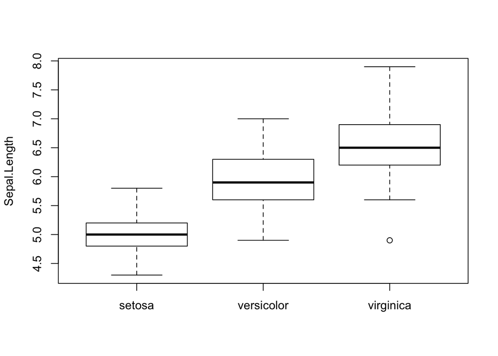

```r
 boxplot(iris$Sepal.Length ~ iris$Species,ylab="Sepal.Length")
```

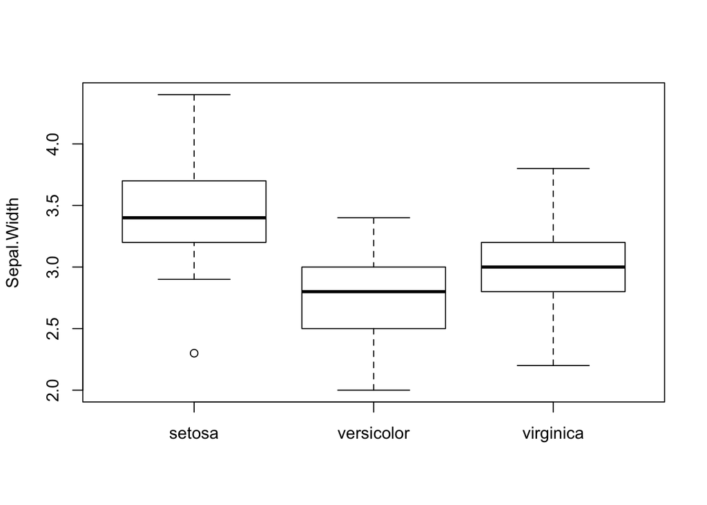

```r
 boxplot(iris$Sepal.Width ~ iris$Species,ylab="Sepal.Width")
```

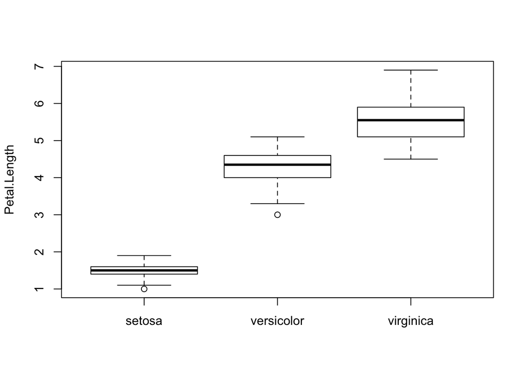

```r
 boxplot(iris$Petal.Length ~ iris$Species,ylab="Petal.Length")
```

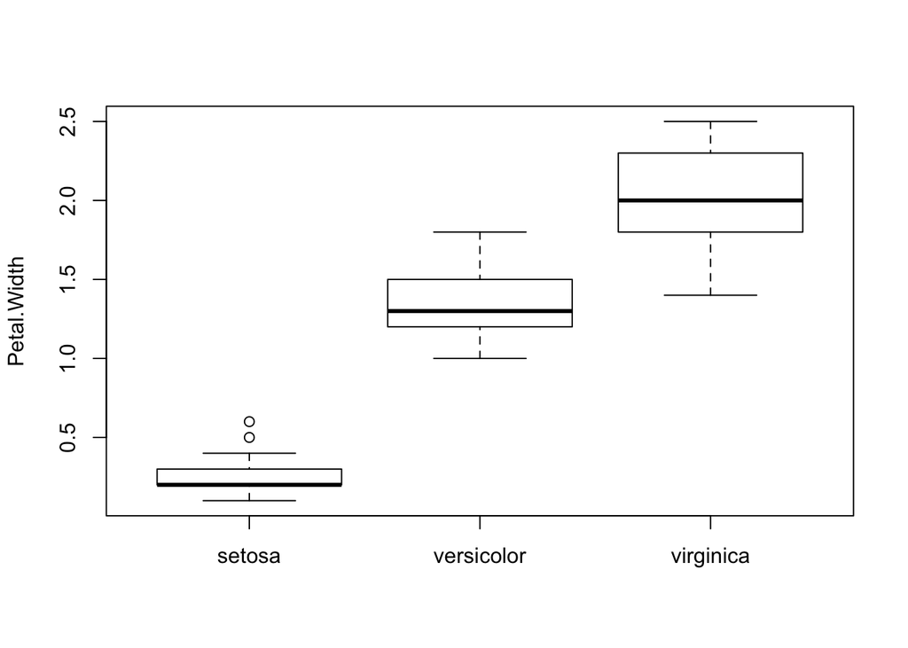

```r
 boxplot(iris$Petal.Width ~ iris$Species,ylab="Petal.Width")
```

We can see that petal descriptors show more differentiation betwen species tat sepal descriptors and that virginica and versicolor are closer to each other than to setosa for most variables.

### A simple plot using petal descriptors

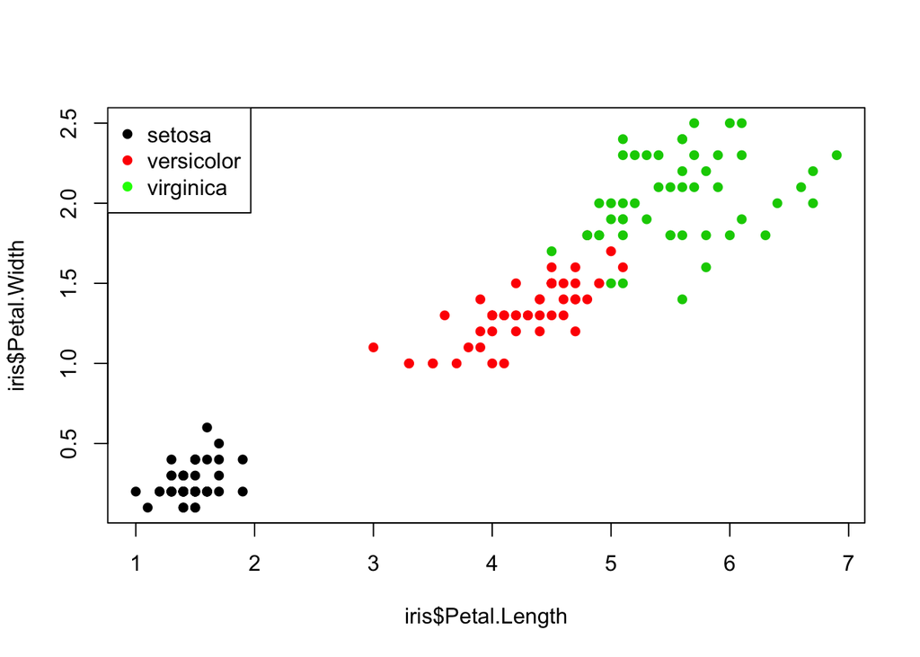

```r
 plot(iris$Petal.Length,iris$Petal.Width,col=iris$Species,pch=16)
 legend( x="topleft",
        legend=levels(as.factor(iris$Species)),
        col=c("black","red","green"),
        pch=c(16) )
```

### Using PCA to show differentiation between species. We won’t try to predict anything with PCA for this example.

```r
log.ir <- log(iris[, 1:4])
ir.species <- iris[, 5]

ir.pca <- prcomp(log.ir,
                 center = TRUE,
                 scale. = FALSE)
ir.pca
```

```
## Standard deviations (1, .., p=4):
## [1] 1.14655938 0.13835264 0.13525746 0.05380941
##
## Rotation (n x k) = (4 x 4):
##                      PC1           PC2        PC3         PC4
## Sepal.Length  0.10090019 -0.0008537483 -0.4891583  0.86633858
## Sepal.Width  -0.05759298  0.5745110809 -0.7140592 -0.39590340
## Petal.Length  0.50527032 -0.6870939247 -0.4269180 -0.30057416
## Petal.Width   0.85510473  0.4447900940  0.2618865  0.04871476
```

```r
pca.results<-cbind(as.data.frame(ir.pca$x),ir.species)
head(pca.results)
```

```
##          PC1         PC2         PC3          PC4 ir.species
## 1 -1.6736850  0.02055683 -0.06042345  0.015217731     setosa
## 2 -1.6688436 -0.06797029  0.06921821  0.041588345     setosa
## 3 -1.7142099  0.02006252  0.07515646  0.002209602     setosa
## 4 -1.6422467 -0.09648282  0.04725452 -0.046865053     setosa
## 5 -1.6773055  0.03675822 -0.07085250 -0.013090995     setosa
## 6 -0.9833353  0.25757951 -0.06701669 -0.002697639     setosa
```

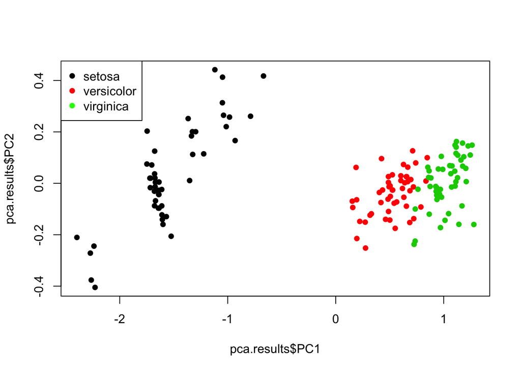

```r
plot(pca.results$PC1,pca.results$PC2,col=pca.results$ir.species,pch=16)
 legend( x="topleft",
        legend=levels(as.factor(pca.results$ir.species)),
        col=c("black","red","green"),
        pch=c(16) )
```

We notice the species separate over PC1. Still some overlp between versicolor and virginica.

## Now using the Random Forest method

### First we split iris data into a training and a testing set

70% of the data will be used for training the model.

```r
ind <- sample(2,nrow(iris),replace=TRUE,prob=c(0.7,0.3))
table(ind)
```

```
## ind
##  1  2
## 97 53
```

```r
trainData <- iris[ind==1,]
testData <- iris[ind==2,]
dim(trainData)
```

```
## [1] 97  5
```

```r
dim(testData)
```

```
## [1] 53  5
```

```r
head(trainData)
```

```
##    Sepal.Length Sepal.Width Petal.Length Petal.Width Species
## 5           5.0         3.6          1.4         0.2  setosa
## 6           5.4         3.9          1.7         0.4  setosa
## 7           4.6         3.4          1.4         0.3  setosa
## 8           5.0         3.4          1.5         0.2  setosa
## 11          5.4         3.7          1.5         0.2  setosa
## 12          4.8         3.4          1.6         0.2  setosa
```

```r
head(testData)
```

```
##    Sepal.Length Sepal.Width Petal.Length Petal.Width Species
## 1           5.1         3.5          1.4         0.2  setosa
## 2           4.9         3.0          1.4         0.2  setosa
## 3           4.7         3.2          1.3         0.2  setosa
## 4           4.6         3.1          1.5         0.2  setosa
## 9           4.4         2.9          1.4         0.2  setosa
## 10          4.9         3.1          1.5         0.1  setosa
```

### Loading randomForest package and generating the Random Forest Learning Tree

If the package has not been installed previously you might need to install it with `install.packages("randomForest")`

```r
library(randomForest)


iris_rf <- randomForest(Species~.,data=trainData,ntree=100,proximity=TRUE)
print(iris_rf)
```

```
##
## Call:
##  randomForest(formula = Species ~ ., data = trainData, ntree = 100,      proximity = TRUE)
##                Type of random forest: classification
##                      Number of trees: 100
## No. of variables tried at each split: 2
##
##         OOB estimate of  error rate: 7.22%
## Confusion matrix:
##            setosa versicolor virginica class.error
## setosa         34          0         0  0.00000000
## versicolor      0         28         3  0.09677419
## virginica       0          4        28  0.12500000
```

```r
#table(predict(iris_rf),trainData$Species)
```

## Importance of the class descriptors

```r
importance(iris_rf)
```

```
##              MeanDecreaseGini
## Sepal.Length         5.714656
## Sepal.Width          3.101009
## Petal.Length        24.865751
## Petal.Width         30.130563
```

We can see that Petal.width and Petal.length are the more important descriptors that differentiate between species as shown before by PCA and just plotting this variables.

## Now we build a random forest for our testing data

```r
  irisPred<-predict(iris_rf,newdata=testData)
  table(irisPred, testData$Species)
```

```
##
## irisPred     setosa versicolor virginica
##   setosa         16          0         0
##   versicolor      0         19         2
##   virginica       0          0        16
```

## Plotting the margins. Positive margins mean correct classification.

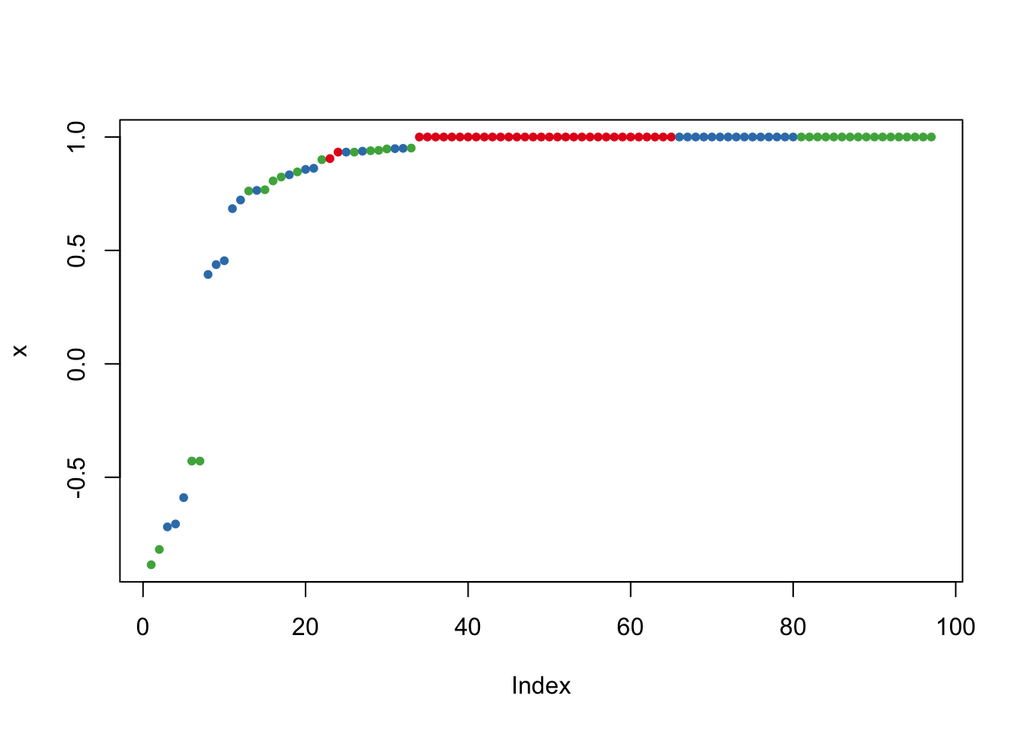

```r
plot(margin(iris_rf,testData$Species))
```

## And checking the classification accuracy

```r
  #The number of correct predictions
  print(sum(irisPred==testData$Species))
```

```
## [1] 51
```

```r
  #out of this many datapoints used to test the prediction
  print(length(testData$Species))
```

```
## [1] 53
```

```r
  #the accuracy
  print(sum(irisPred==testData$Species)/length(testData$Species))
```

```
## [1] 0.9622642
```